# Making a poster in the MPI theme

This package contains themes and scales consistent with the MPI for Psycholinguistics corporate identity, and also helper functions to produce figures suitable for use in the poster and slide templates.

# Designing a poster

On Maxintra, there are poster templates available in Adobe Illustrator and in Powerpoint. There are separate templates for portrait and landscape posters. We encourage you to use the Illustrator templates if possible. There is example content, which of course you can remove. The templates include (we hope) helpful tips and suggestions.

Take a look at the poster template that you are going to use. We suggest that you first make a sketch (on paper) of the poster design and layout.

# Making a plot to insert into the poster

This is where this package comes in!

You can create your plot in the normal way, and then use the themes and scale functions provided by the package.

Here’s an example. Here’s what it looks like in base ggplot:

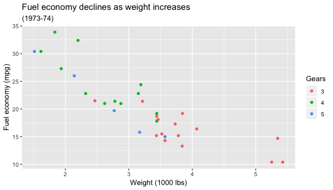

```r
mtcars2 <- within(mtcars, {
  vs <- factor(vs, labels = c("V-shaped", "Straight"))
  am <- factor(am, labels = c("Automatic", "Manual"))
  cyl  <- factor(cyl)
  gear <- factor(gear)
})

library(ggplot2)

ggplot(mtcars2) +
  geom_point(aes(x = wt, y = mpg, colour = gear)) +
  labs(title = "Fuel economy declines as weight increases",
       subtitle = "(1973-74)",
       x = "Weight (1000 lbs)",
       y = "Fuel economy (mpg)",
       color = "Gears")
```

```r
library(mpinltheme)
```

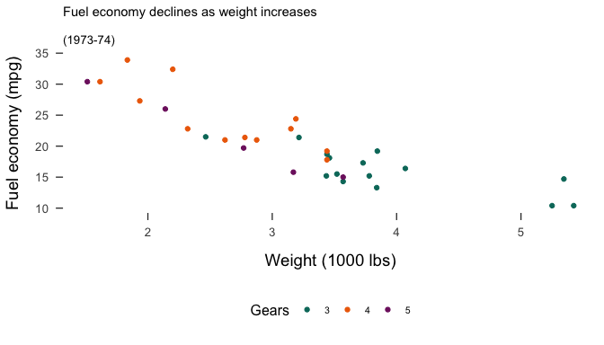

```r
ggplot(mtcars2) +
  geom_point(aes(x = wt, y = mpg, colour = gear)) +
  scale_colour_discrete_mpinl() +
  labs(title = "Fuel economy declines as weight increases",
       subtitle = "(1973-74)",
       x = "Weight (1000 lbs)",
       y = "Fuel economy (mpg)",
       color = "Gears")+
  theme_mpinl_general()
```

## Theme version for posters

There is also a version of the theme that is specifically intended for posters. This looks wierd here, because the fonts are relatively large, but when exported and inserted into a poster, they will magically be the correct size to coordinate with the poster template.

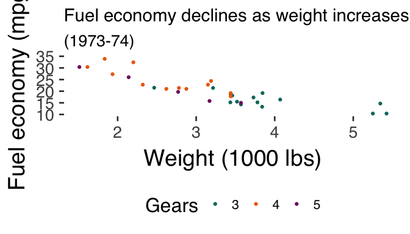

```r
library(mpinltheme)

ggplot(mtcars2) +
  geom_point(aes(x = wt, y = mpg, colour = gear)) +
  scale_colour_discrete_mpinl() +
  labs(title = "Fuel economy declines as weight increases",
       subtitle = "(1973-74)",
       x = "Weight (1000 lbs)",
       y = "Fuel economy (mpg)",
       color = "Gears")+
  theme_mpinl_poster()
```

# Exporting plots and inserting them into Illustrator or Powerpoint

We have provided some helper functions that make it super easy to export a plot for use in the poster templates. The helper functions save a file with the width set to be the right width for the column of the poster templates, so all you have to define is the height. Because the portrait and landscape poster templates have different column widths, there are separate functions for each. For use in Illustrator, it is best to save pdfs (just specify a filename with .pdf). For Powerpoint, save pngs.

```r
library(mpinltheme)

p1 <- ggplot(mtcars2) +
  geom_point(aes(x = wt, y = mpg, colour = gear),size=3) +
  scale_colour_discrete_mpinl() +
  labs(title = "Fuel economy declines as weight increases",
       subtitle = "(1973-74)",
       x = "Weight (1000 lbs)",
       y = "Fuel economy (mpg)",
       color = "Gears")+
  theme_mpinl_poster()

ggsave_mpinl_poster_landscape("figure1.pdf",p1,height = 200,units = "mm")
ggsave_mpinl_poster_portrait("figure1_portrait.pdf",p1,height = 200,units = "mm")
ggsave_mpinl_poster_portrait("figure1_portrait.png",p1,height = 200,units = "mm")
```